**PRM Release MillFrame 4.1.0**

**Web Portal User Guide**

Confidential and Proprietary

© 2016 Milliman, Inc. All rights reserved.  
Milliman® is a trademark of Milliman, Inc.  
All other trademarks belong to their respective owners

This manual and its contents are the confidential property of Milliman, Inc. and are prepared for the exclusive use of Milliman, Inc. and its subscribing clients. Any distribution or reproduction, intentional or unintentional, of any materials contained herein without the express written permission of Milliman, Inc. is prohibited.

**Introduction**

Milliman PRM Analytics is a predictive analytics solution capable of predicting any number of healthcare management risks. The primary predictive analytics are the Opportunity Prospective Scores.

Milliman PRM Analytics is not a standalone solution. It can also be integrated with an existing care management system for comprehensive care management. The PRM Care Coordinator Reports provide care managers with a comprehensive view of recent patient clinical and claims activity, making management more efficient and effective.

Milliman PRM Analytics are backed by more than 65 years of experience in healthcare consulting, data analytics, operational analysis and problem solving. The solutions offered by this tool leverage a unique reporting structure and custom analytics that help meet coming healthcare challenges head on.

This user guide is designed to give users an understanding of the latest features of the PRM Web Portal and step by step instructions for using the system.

Please note that these instructions are ONLY meant for internal users who have been granted access.

*Note: Access to various functionality is dictated by what was enabled for the role assigned to the user and the options enabled for the client. For illustration purposes, all of the functionality is enabled in the screen shots shown below.*

**Technical Support**

If you are having any technical difficulty with the product, please contact our technical support team by email: *prm.support@milliman.com*

*Note: For the purpose of this user guide, all data has been de-identified to protect patients personal health information (PHI) in accordance with the Health Insurance Portability and Accountability Act of 1996 (HIPAA).*

## Overview

Millframe 4.1.0 is an application that allows the Milliman administrators to add and manage users, and set different roles for the users. It allows the Client Administrators to add and manage users, and set data restrictions for them. The Client users can view the Qlikview reports using Web Portal interface. The application also allows the Client Publisher to publish the contents for a Client. The application Millframe consists of five modules. The PRM Web Portal module allows the client users to view the reports for the group(s) they are associated with.

## Web Portal Users

There are 3 kinds of users of the PRM Web Portal:

- Client Users
- Client User Administrators
- Client Publisher Administrators

## Login to the Web Portal [password must be a minimum of 8 characters; one uppercase letter, a number and a special character].

[figure not shown]

- After logging in you see the **Web Portal console**.

[figure not shown]

- Clicking on **Products** will reveal a list of reports available to licensed users.
- Clicking on the individual report will launch that report.

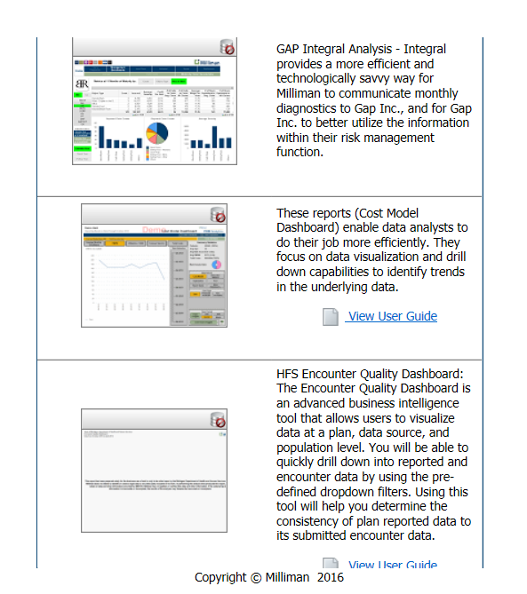

- Clicking on the **Profile** tab allows a user to view profile information, including name, email address, phone number and password recovery settings including security questions.
- You may also use the profile to change your password.

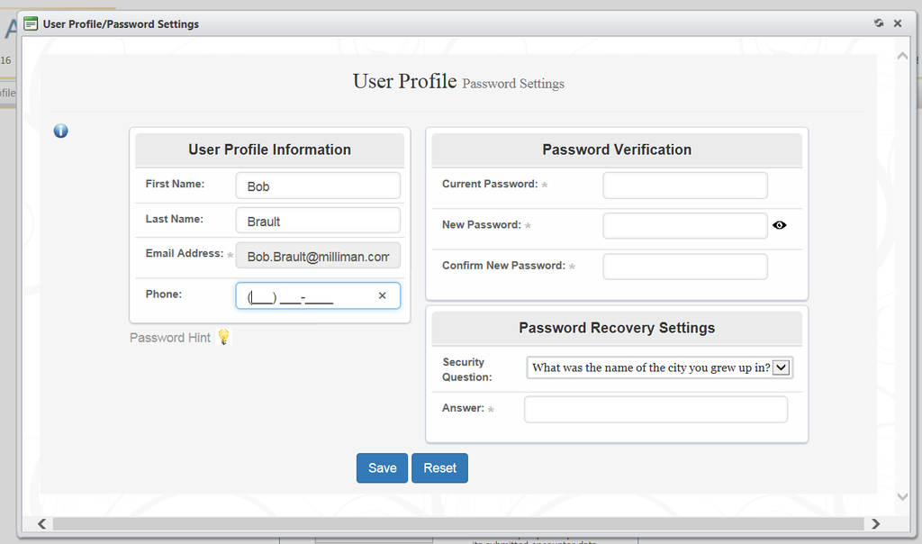

- Clicking on the **Help** screen takes the user to either the **Support** link to the PRM Support Team email at prm.support@milliman.com or the **About Milliman** link taking the user to the Milliman company web site.

[figure not shown]

- Clicking on the **User Administration** tab gives the user a scroll down list of groups of various clients.

[figure not shown]

- Finally, **Logout** allows the user to log out of the PRM Web Console, and return to the initial intro screen which contains links to the Milliman web site. **Terms of Use**, **Privacy Policy**, and **Copyright** disclaimers.

[figure not shown]